# atmo

2024-2025 BARKIRE DOURAMANE & KARAMA FABARIKA **PROJET D’ANALYSE MULTIVARIEE DES POLLUANTS ATMOSPHERIQUES A PERIGUEUX en 2024**  
M1 IREF RDSM

## Introduction

Ce projet explore les relations entre les paramètres climatiques et les niveaux de pollution atmosphérique dans une base de données ATMO. Nous appliquons des méthodes d’**Analyse en Composantes Principales (ACP)** et de visualisation pour mieux comprendre les interactions entre les variables météorologiques et de pollution.

## Chargement des Bibliothèques et des Données

```r
# Charger les bibliothèques nécessaires

library(readr)
library(tidyr)
library(dplyr)
library(ggplot2)
library(lubridate) # pour la gestion des format date
library(MASS)
library(FactoMineR)
library(corrplot)
library(factoextra)
library(plotly)
library(naniar)
library(Factoshiny)
```

```r
# Charger les données
load("ATMO-RDSM.rda")
# Aperçu des données
glimpse(df)
```

```
Rows: 8,696
Columns: 28
$ date_debut             <dttm> 2023-11-08 00:00:00, 2023-11-08 01:00:00, 2023…
$ date_debut_standard    <dbl> 45238.00, 45238.04, 45238.08, 45238.12, 45238.1…
$ NO2                    <dbl> 3, 3, 3, 6, 4, 6, 8, 9, 13, 7, 5, 3, 4, 3, 3, 3…
$ PM2.5                  <dbl> NA, NA, NA, NA, NA, NA, NA, NA, NA, NA, NA, NA,…
$ O3                     <dbl> 34, 32, 34, 31, 26, 22, 25, 47, 48, 54, 58, 64,…
$ NO                     <dbl> 3.6, 3.9, 3.4, 5.9, 3.7, 7.1, 9.7, 11.7, 20.3, …
$ PM10                   <dbl> 11, 11, 10, 10, 12, 12, 12, 9, 10, 10, 9, 8, 9,…
$ temperature            <dbl> 7.1, 7.5, 8.1, 8.4, 8.6, 8.9, 8.7, 8.9, 9.6, 10…
$ pression               <dbl> 1018.6, 1018.1, 1018.5, 1018.3, 1018.6, 1018.6,…
$ pression_variation_3h  <dbl> 0.0, 0.0, 0.0, -0.3, 0.5, 0.1, 0.3, 0.3, 0.5, 0…
$ humidite               <dbl> 94, 95, 95, 95, 95, 95, 95, 94, 94, 91, 89, 87,…
$ point_de_rosee         <dbl> 6.1, 6.7, 7.2, 7.8, 7.8, 8.3, 7.8, 8.3, 8.9, 9.…
$ vent_moyen             <dbl> 0.0, 0.0, 0.0, 0.0, 0.0, 0.0, 0.0, 0.0, 1.6, 3.…
$ vent_rafales           <dbl> 0, 0, 0, 0, 0, 0, 0, 0, 0, 0, 0, 0, 0, 0, 0, 0,…
$ vent_rafales_10min     <dbl> 0.0, 0.0, 0.0, 0.0, 0.0, 0.0, 0.0, 0.0, 8.0, 9.…
$ vent_direction         <dbl> 110, 110, 110, 110, 110, 110, 110, 110, 150, 92…
$ temperature_min        <dbl> 7.1, 7.1, 7.1, 7.1, 7.1, 7.1, 7.1, 7.1, 7.1, 7.…
$ temperature_max        <dbl> 7.1, 7.5, 8.1, 8.4, 8.6, 8.9, 8.9, 8.9, 9.6, 10…
$ pluie_1h               <dbl> 0.0, 0.0, 0.0, 0.0, 0.0, 0.0, 0.0, 0.0, 0.0, 0.…
$ pluie_3h               <dbl> 0.0, 0.0, 0.0, 0.0, 0.0, 0.0, 0.0, 0.0, 0.0, 0.…
$ pluie_6h               <dbl> 0.0, 0.0, 0.0, 0.0, 0.0, 0.0, 0.0, 0.0, 0.0, 0.…
$ pluie_12h              <dbl> 0.6, 0.6, 0.6, 0.6, 0.6, 0.0, 0.0, 0.0, 0.0, 0.…
$ pluie_24h              <dbl> 1.6, 1.6, 1.2, 0.8, 0.8, 0.8, 0.6, 0.6, 0.6, 0.…
$ pluie_cumul_0h         <dbl> 0.0, 0.0, 0.0, 0.0, 0.0, 0.0, 0.0, 0.0, 0.0, 0.…
$ pluie_intensite        <dbl> 0.0, 0.0, 0.0, 0.0, 0.0, 0.0, 0.0, 0.0, 0.0, 0.…
$ pluie_intensite_max_1h <dbl> 0, 0, 0, 0, 0, 0, 0, 0, 0, 0, 0, 0, 0, 0, 0, 0,…
$ jour                   <ord> mercredi, mercredi, mercredi, mercredi, mercred…
$ heure                  <int> 0, 1, 2, 3, 4, 5, 6, 7, 8, 9, 10, 11, 12, 13, 1…
```

## Gestion des Données Manquantes

```r
# Résumé des données manquantes
print(miss_var_summary(df), n=35)
```

```
# A tibble: 28 × 3
   variable               n_miss pct_miss
   <chr>                   <int>    <num>
 1 PM2.5                    7955    91.5
 2 NO2                       545     6.27
 3 NO                        542     6.23
 4 PM10                      300     3.45
 5 date_debut                  0     0
 6 date_debut_standard         0     0
 7 O3                          0     0
 8 temperature                 0     0
 9 pression                    0     0
10 pression_variation_3h       0     0
11 humidite                    0     0
12 point_de_rosee              0     0
```

[output cut: 16 more lines]

```r
# Suppression de la variable PM2.5
df$PM2.5 <- NULL

# Suppression des lignes avec des valeurs manquantes
df <- df %>% na.omit()
```

## Transformation des Variables

```r
# Ajouter des colonnes pour le jour et l'heure
df <- df %>%
  mutate(jour = wday(date_debut, label = TRUE, abbr = FALSE),
         heure = hour(date_debut))

# Générer des noms de lignes basés sur les dates
rownames.df <- paste(df$date_debut %>% day(),
                     df$date_debut %>% month(),
                     df$date_debut %>% hour(), sep = ".")
```

## Analyse des Corrélations (2.1)

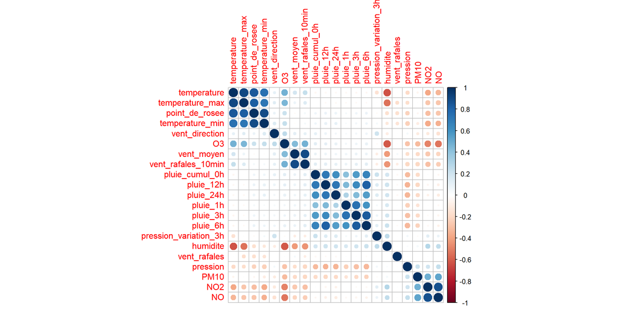

```r
corrplot(cor(df[3:23]), method = "circle", number.cex = 0.7, order = "hclust")
```

Variables climatiques : Les variables liées à la température (comme temperature, temperature_max, point_de_rosee, et temperature_min) montrent des corrélations fortement positives entre elles. Cela indique qu’elles évoluent de manière similaire, ce qui est attendu étant donné leur interdépendance naturelle. Par exemple, une augmentation de la température maximale est généralement associée à une augmentation de la température moyenne.

Corrélations entre pollution et météo : Les variables de pollution (comme NO, NO2, O3) présentent des corrélations intéressantes avec les variables climatiques. Par exemple :

O3 est positivement corrélé avec la température mais négativement avec l’humidité. NO et NO2 sont légèrement corrélés avec les variables de vent, ce qui pourrait indiquer un lien entre la dispersion des polluants et la force du vent.

## Analyse des Corrélations avec l’Ozone (2.2)

### Extraction des Variables Corrélées avec O3

```r
# Calculer les corrélations pour les colonnes sélectionnées
cor_matrix <- cor(df[3:23], use = "complete.obs")

# Extraire les corrélations de O3 avec les autres variables
cor_ozone <- cor_matrix["O3", ]

# Filtrer les variables corrélées fortement avec O3
significant_vars <- names(cor_ozone[abs(cor_ozone) > 0.3 & names(cor_ozone) != "O3"])
```

### Visualisation des Relations avec O3

#### - Relation entre O3 et NO2

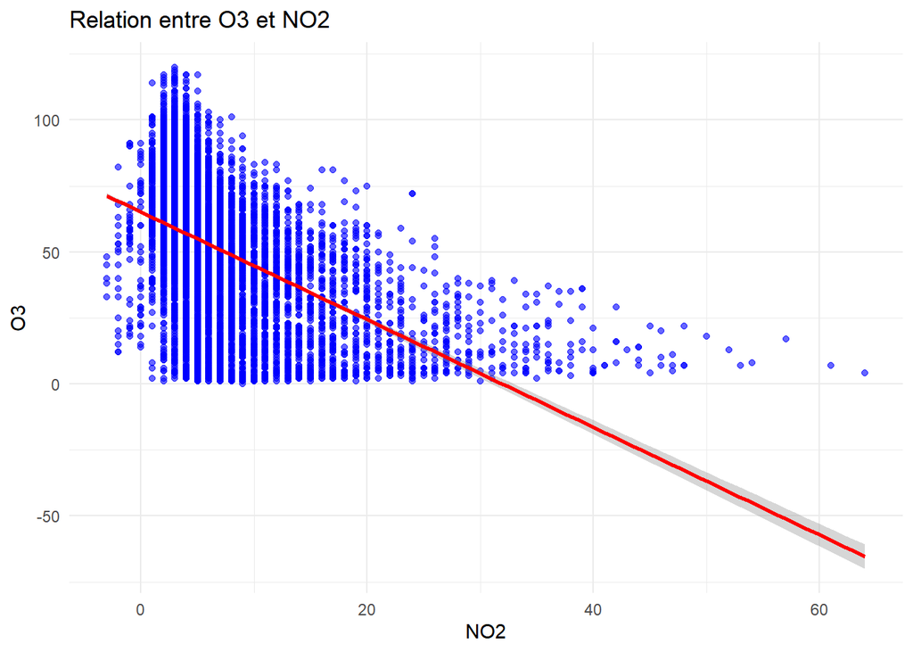

```r
ggplot(df, aes(x = NO2, y = O3)) +
  geom_point(color = "blue", alpha = 0.6) +
  geom_smooth(method = "lm", color = "red", se = TRUE) +
  ggtitle("Relation entre O3 et NO2") +
  xlab("NO2") + ylab("O3") +
  theme_minimal()
```

Interprétation : Une forte corrélation négative est observée entre O3 et NO2. Cela signifie qu’à mesure que la concentration de NO augmente, les niveaux d’ozone diminuent. Ce phénomène est attendu car NO2 joue un rôle dans la destruction de l’ozone par des réactions photochimiques.

#### - Relation entre O3 et PM10

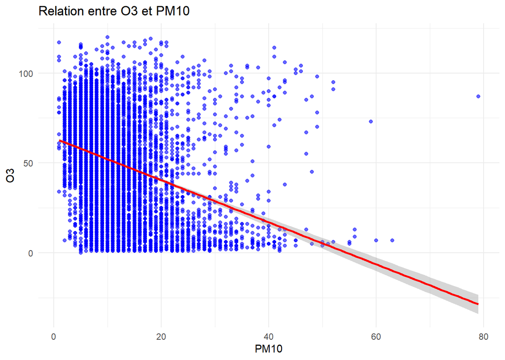

```r
ggplot(df, aes(x = PM10, y = O3)) +
  geom_point(color = "blue", alpha = 0.6) +
  geom_smooth(method = "lm", color = "red", se = TRUE) +
  ggtitle("Relation entre O3 et PM10") +
  xlab("PM10") + ylab("O3") +
  theme_minimal()
```

Interprétation : Une corrélation négative modérée est visible entre O3 et PM10. Cela pourrait indiquer que des niveaux élevés de particules fines PM10 sont associés à une réduction de la concentration d’ozone, probablement en raison des conditions atmosphériques favorisant l’accumulation de particules et la dispersion limitée de l’ozone.

#### - Relation entre O3 et la température

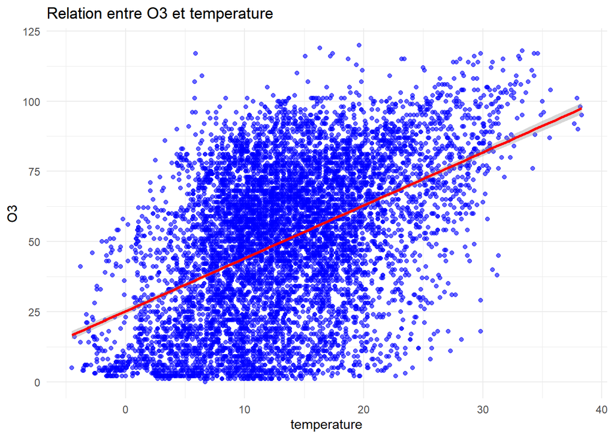

```r
ggplot(df, aes(x = temperature, y = O3)) +
  geom_point(color = "blue", alpha = 0.6) +
  geom_smooth(method = "lm", color = "red", se = TRUE) +
  ggtitle("Relation entre O3 et temperature") +
  xlab("temperature") + ylab("O3") +
  theme_minimal()
```

Interprétation : Une corrélation positive marquée est observée. Les niveaux d’ozone augmentent avec la température. Cela s’explique par le fait que des températures plus élevées favorisent les réactions photochimiques qui produisent de l’ozone.

#### - Relation entre O3 et l’humidité

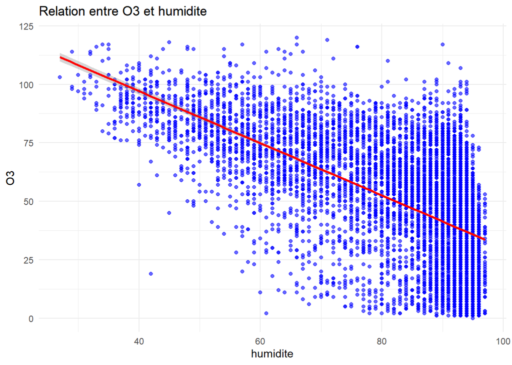

```r
ggplot(df, aes(x = humidite, y = O3)) +
  geom_point(color = "blue", alpha = 0.6) +
  geom_smooth(method = "lm", color = "red", se = TRUE) +
  ggtitle("Relation entre O3 et humidite") +
  xlab("humidite") + ylab("O3") +
  theme_minimal()
```

Interprétation : Une corrélation négative est constatée entre O3 et l’humidité. Une humidité plus élevée est souvent associée à des conditions météorologiques nuageuses ou pluvieuses, qui réduisent l’intensité du rayonnement solaire nécessaire à la formation de l’ozone.

#### - Relation entre O3 et le vent moyen

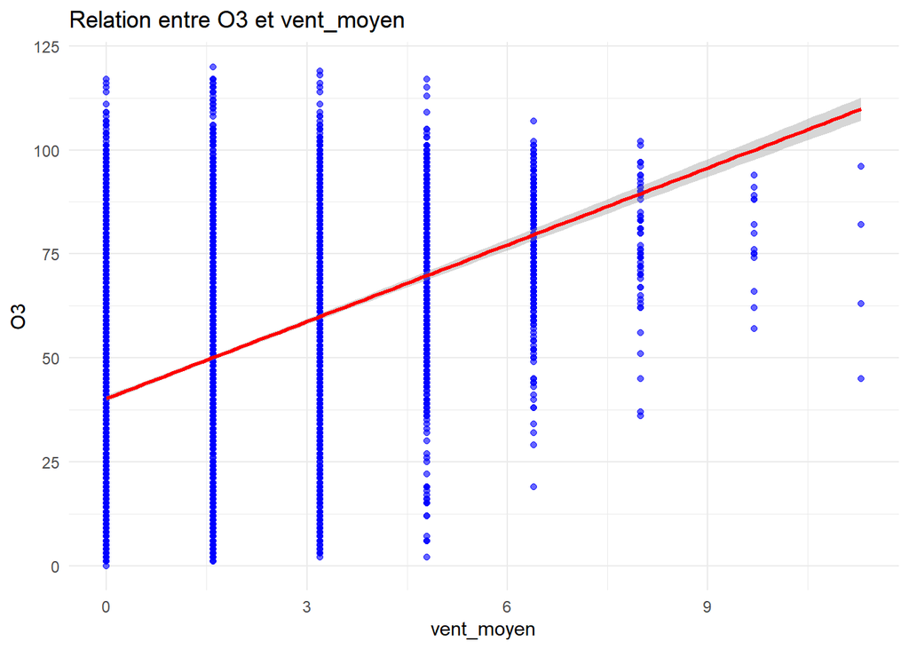

```r
ggplot(df, aes(x = vent_moyen, y = O3)) +
  geom_point(color = "blue", alpha = 0.6) +
  geom_smooth(method = "lm", color = "red", se = TRUE) +
  ggtitle("Relation entre O3 et vent_moyen") +
  xlab("vent_moyen") + ylab("O3") +
  theme_minimal()
```

Interprétation : Une légère corrélation positive est observée entre O3 et vent_moyen. Cela pourrait indiquer que des vents modérés contribuent à la dispersion des polluants précurseurs de l’ozone, favorisant sa formation.

#### - Relation entre O3 et vent_rafales_10min

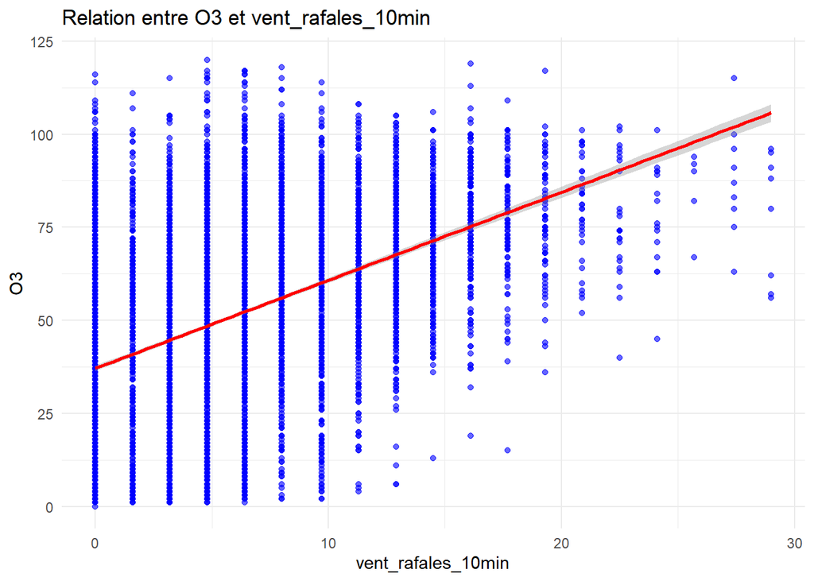

```r
ggplot(df, aes(x = vent_rafales_10min, y = O3)) +
  geom_point(color = "blue", alpha = 0.6) +
  geom_smooth(method = "lm", color = "red", se = TRUE) +
  ggtitle("Relation entre O3 et vent_rafales_10min") +
  xlab("vent_rafales_10min") + ylab("O3") +
  theme_minimal()
```

Interprétation : Une corrélation similaire à celle avec le vent moyen est notée. Les rafales de vent semblent également contribuer à la dispersion des précurseurs de l’ozone, bien qu’avec une variabilité plus importante.

#### - Relation entre O3 et temperature_max

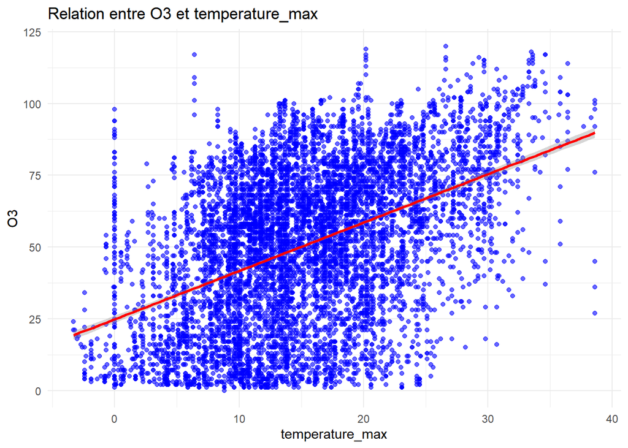

```r
ggplot(df, aes(x = temperature_max, y = O3)) +
  geom_point(color = "blue", alpha = 0.6) +
  geom_smooth(method = "lm", color = "red", se = TRUE) +
  ggtitle("Relation entre O3 et temperature_max") +
  xlab("temperature_max") + ylab("O3") +
  theme_minimal()
```

Interprétation : Une relation positive est claire entre O3 et temperature_max. Cela confirme que des températures maximales élevées augmentent les niveaux d’ozone, ce qui est typique des journées chaudes et ensoleillées.

## 2.2 Analyse des Tendances Journalières et Hebdomadaires

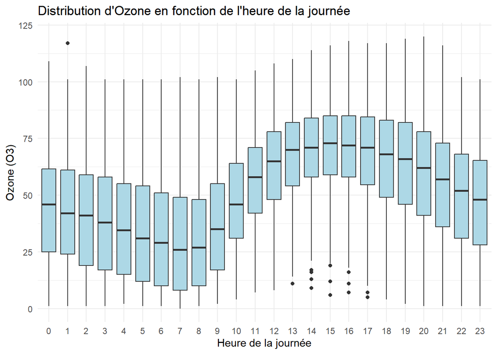

```r
df$heure <- as.factor(df$heure)  # Convertir l'heure en facteur si ce n'est pas déjà le cas

# Boîtes à moustaches pour Ozone en fonction de l'heure
ggplot(df, aes(x = heure, y = O3)) +
  geom_boxplot(fill = "lightblue") +
  ggtitle("Distribution d'Ozone en fonction de l'heure de la journée") +
  xlab("Heure de la journée") +
  ylab("Ozone (O3)") +
  theme_minimal()
```

### Tendance générale:

- Les boîtes à moustaches montrent une variation notable des concentrations d’ozone (O3) au cours de la journée.
- On observe que les concentrations d’ozone sont généralement plus faibles le matin (entre 0h et 9h).
- Les concentrations augmentent progressivement et atteignent un pic entre 12h et 16h, avant de diminuer légèrement en soirée.

### Explication scientifique :

- La production d’ozone est fortement influencée par le **rayonnement solaire**. L’intensité du soleil augmente au fil de la matinée, atteignant son maximum dans l’après-midi, ce qui favorise les réactions photochimiques responsables de la formation d’ozone.
- En fin d’après-midi et en soirée, le rayonnement solaire diminue, ce qui explique la baisse progressive des niveaux d’ozone.

### Outliers(Valeurs aberrantes):

- Des points atypiques (outliers) sont visibles pour certaines heures, notamment autour de 13h à 17h. Ces valeurs pourraient correspondre à des conditions météorologiques particulières ou des anomalies dans les sources de pollution.

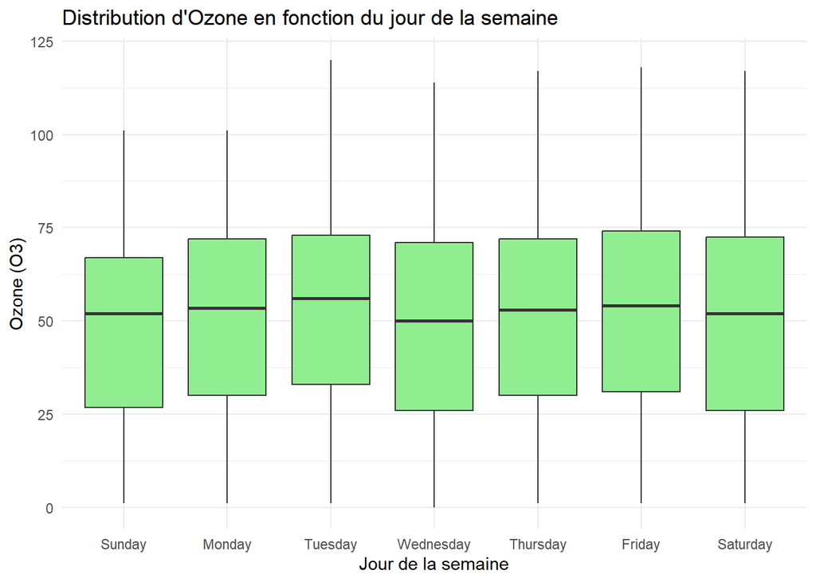

```r
df$jour <- as.factor(df$jour)  # Convertir le jour en facteur si ce n'est pas déjà le cas

# Boîtes à moustaches pour Ozone en fonction du jour de la semaine
ggplot(df, aes(x = jour, y = O3)) +
  geom_boxplot(fill = "lightgreen") +
  ggtitle("Distribution d'Ozone en fonction du jour de la semaine") +
  xlab("Jour de la semaine") +
  ylab("Ozone (O3)") +
  theme_minimal()
```

Les niveaux d’ozone (O3) restent globalement stables tout au long de la semaine, avec des distributions et des médianes similaires entre les jours. Il n’y a pas de différence notable entre les jours ouvrables et le week-end, ce qui indique que l’ozone est davantage influencé par des facteurs climatiques que par les variations hebdomadaires d’activités humaines.

## Analyse en Composantes Principales (ACP) - 2.3

### Réalisation de l’ACP

#### Sélection des Variables Numériques

```r
numeric_vars = c("NO2", "O3", "NO", "PM10", "temperature", "temperature_min",
                  "temperature_max", "pression", "pression_variation_3h",
                  "humidite", "point_de_rosee", "vent_moyen", "vent_rafales",
                  "vent_rafales_10min", "vent_direction", "pluie_1h",
                  "pluie_3h", "pluie_6h", "pluie_12h", "pluie_24h",
                  "pluie_cumul_0h", "pluie_intensite", "pluie_intensite_max_1h")
```

#### Calcul des Statistiques Descriptives

```r
moyennes <- apply(df[, numeric_vars], 2, mean)
sdn <- function(x){sqrt(mean((x-mean(x))^2, na.rm = TRUE))}
ec.type <- apply(df[, numeric_vars], 2,sdn)
```

## Préparation des Données pour l’ACP

### Conversion des Variables Qualitatives

```r
df$heure <- as.numeric(as.character(df$heure))
jours <- c("Monday", "Tuesday", "Wednesday", "Thursday", "Friday", "Saturday", "Sunday")
df$jour <- as.numeric(factor(df$jour, levels = jours))
```

## Réalisation de l’ACP

```
         eigenvalue percentage of variance cumulative percentage of variance
comp 1  5.237946864            22.77368202                          22.77368
comp 2  4.518372028            19.64509577                          42.41878
comp 3  2.428103530            10.55697187                          52.97575
comp 4  1.624593669             7.06345073                          60.03920
comp 5  1.419210594             6.17048084                          66.20968
comp 6  1.232341729             5.35800752                          71.56769
comp 7  1.023319208             4.44921395                          76.01690
comp 8  0.801136409             3.48320178                          79.50010
comp 9  0.738888216             3.21255746                          82.71266
comp 10 0.670623575             2.91575467                          85.62842
comp 11 0.663475404             2.88467567                          88.51309
comp 12 0.561345987             2.44063473                          90.95373
comp 13 0.506390570             2.20169813                          93.15543
comp 14 0.352689807             1.53343394                          94.68886
comp 15 0.286229301             1.24447522                          95.93333
comp 16 0.251944120             1.09540922                          97.02874
comp 17 0.180951416             0.78674529                          97.81549
comp 18 0.133747862             0.58151244                          98.39700
comp 19 0.108395268             0.47128377                          98.86829
comp 20 0.093451762             0.40631201                          99.27460
comp 21 0.092183723             0.40079879                          99.67540
comp 22 0.065141752             0.28322501                          99.95862
comp 23 0.009517207             0.04137916                         100.00000
```

On retrouve bien les résultats d’une ACP normée (somme des valeurs propres= p=23).

- **Comp 1 et Comp 2** : Ces deux composantes expliquent **42.42%** de la variance. Elles capturent une grande partie de l’information structurante des données.
- **Comp 3 à Comp 6** : Apportent des informations complémentaires importantes, portant la variance cumulée à **71.57%**.
- **Comp 7 et suivantes** : Leur contribution à l’information globale devient marginale (chaque axe explique moins de **5%** de la variance).

On va retenir **les 6 premières composantes** pour l’analyse, car elles capturent l’essentiel de la variance des données (**71.57%**).

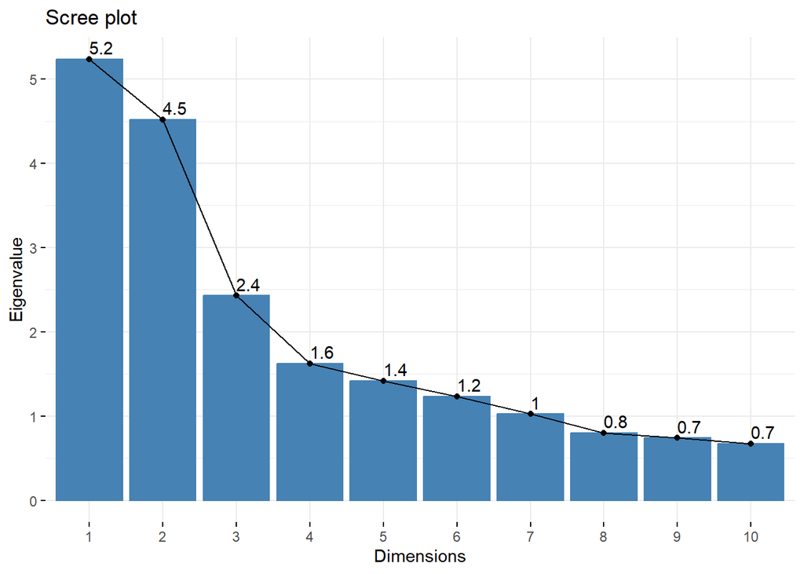

```r
fviz_eig(pca.df, choice = "eigenvalue", addlabels=TRUE)
```

## Visualisation du Plan Factoriel (1-2)

#### Cercle des Corrélations

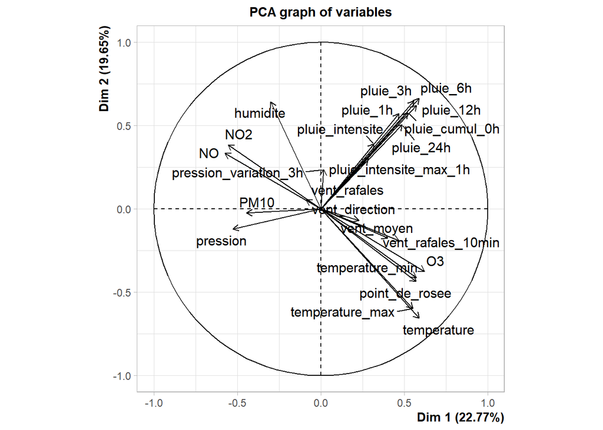

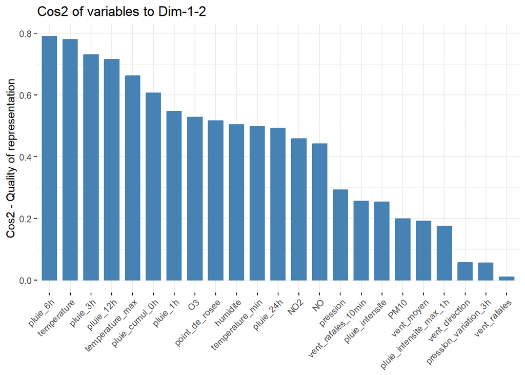

```r
fviz_cos2(pca.df, choice="var", axes = c(1,2))
```

Le graphique montre la qualité de représentation (Cos2) des variables sur les deux premières composantes principales (Dim 1 et Dim 2). Plus la valeur de Cos2 est élevée, mieux la variable est représentée sur le plan factoriel, et plus elle contribue à l’interprétation des axes.

## 1. Variables bien représentées (Cos2 élevé) :

Ces variables définissent principalement les deux axes et doivent être prioritairement analysées.

## 3. Variables mal représentées (Cos2 faible) :

Les variables avec un Cos2 inférieur à 0.5 sont moins bien projetées sur Dim 1 - 2 et contribuent peu à l’interprétation :

- **vent_direction**, **pression_variation_3h**, **vent_rafales** : Ces variables ne sont pas bien représentées sur le plan et pourraient être mieux décrites par d’autres composantes principales.
- **vent_moyen**, **vent_rafales_10min** : Ces variables liées au vent sont mal projetées, indiquant qu’elles sont peut-être plus liées à des dimensions secondaires.

## Visualisation du plan des individus projetés

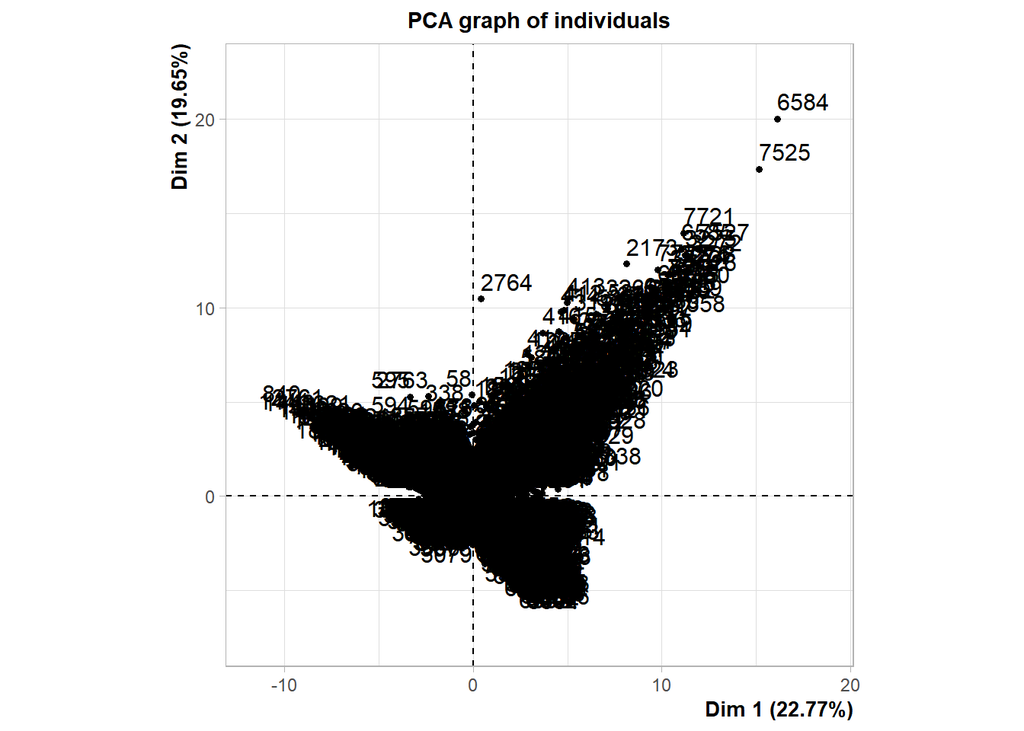

```r
plot.PCA(pca.df)
```

## Interpretation

Globalement, Dim 1 semble être lié aux niveaux de pollution et de précipitations, tandis que Dim 2 reflète davantage les variations climatiques. Les individus extrêmes identifiés permettent de mieux comprendre les pics de pollution, les événements pluvieux intenses, ou encore les conditions atmosphériques standards, fournissant ainsi des informations précieuses pour anticiper et analyser les phénomènes environnementaux inhabituels.

## Analyse statistique des individus extrêmes sur le plan 1-2

## 1. Identification des individus extrêmes

Nous avons identifié des individus spécifiques sur le plan 1-2, qui ont des coordonnées :

Les individus 7525, 6584, et 2764 se démarquent sur ce plan et nécessitent une analyse approfondie.

## 2. Caractérisation des moments extrêmes

Les caractéristiques de ces moments peuvent être justifiées par l’analyse des variables climatiques et de pollution :

## 3. Analyse statistique complémentaire

Nous avons également analysé les corrélations entre les variables pour mieux comprendre ces phénomènes :

## 2.4 Reprendre l’ACP complète en incluant une seule variable de pluie. Comparer.

### Préparation des Données

#### 1. Sélection des Variables

Dans cette analyse, nous conservons une seule variable parmi celles représentant les précipitations : pluie_12h. Les autres variables pertinentes sont également incluses.

```r
# Supprimer toutes les variables de pluie sauf pluie_12h
variables_a_garder <- c("NO2", "O3", "NO", "PM10", "temperature", "pression",
                        "pression_variation_3h", "humidite", "point_de_rosee",
                        "vent_moyen", "vent_rafales", "vent_rafales_10min",
                        "vent_direction", "temperature_min", "temperature_max",
                        "pluie_12h","jour","heure")  # Ajouter uniquement pluie_12h

df_reduit <- df[, variables_a_garder]
```

## Réalisation de l’ACP

Nous appliquons une ACP normée sur les variables sélectionnées afin de comparer les résultats avec l’ACP complète.

```r
# Réalisation de l'ACP
pca.dfP <- PCA(df_reduit, scale.unit = TRUE, graph = FALSE)

# Affichage des valeurs propres
pca.dfP$eig
```

```
         eigenvalue percentage of variance cumulative percentage of variance
comp 1  4.991347560            27.72970867                          27.72971
comp 2  2.465431489            13.69684160                          41.42655
comp 3  1.958841497            10.88245276                          52.30900
comp 4  1.494048561             8.30026978                          60.60927
comp 5  1.268770755             7.04872642                          67.65800
comp 6  1.065216586             5.91786992                          73.57587
comp 7  1.021910105             5.67727836                          79.25315
comp 8  0.872042970             4.84468317                          84.09783
comp 9  0.721293027             4.00718348                          88.10501
comp 10 0.585260189             3.25144549                          91.35646
comp 11 0.522313794             2.90174330                          94.25820
comp 12 0.430335549             2.39075305                          96.64896
comp 13 0.247176661             1.37320367                          98.02216
comp 14 0.112150502             0.62305835                          98.64522
comp 15 0.097072307             0.53929059                          99.18451
comp 16 0.091503296             0.50835164                          99.69286
comp 17 0.045751579             0.25417544                          99.94704
comp 18 0.009533572             0.05296429                         100.00000
```

## Visualisation des Résultats

### Cercle des Corrélations

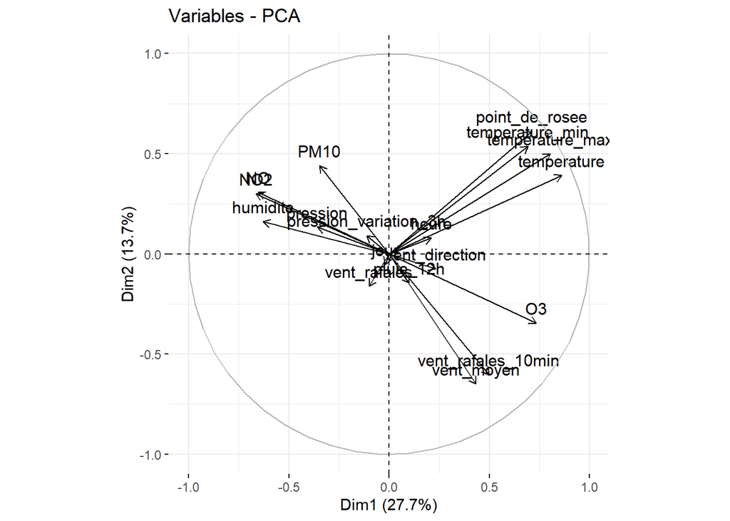

```r
fviz_pca_var(pca.dfP, axes=c(1,2))
```

## Interprétation du nouveau cercle des corrélations

Sur le cercle des corrélations obtenu avec la variable pluie_12h, nous observons plusieurs groupes de variables qui présentent des relations intéressantes :

#### - Relation NO2 et PM10 :

- Ces deux polluants sont proches sur le cercle, ce qui indique qu’ils sont positivement corrélés et capturent des dynamiques similaires dans le jeu de données.

## Comparaison avec l’ACP complète :

En incluant uniquement pluie_12h parmi les variables de précipitations, la contribution des variables aux composantes principales est légèrement modifiée, mais les groupes principaux de corrélations restent similaires. Cette simplification permet de mieux comprendre l’impact spécifique de la précipitation à 12 heures sans interférer avec d’autres mesures liées aux précipitations.

## Visualisation des Individus

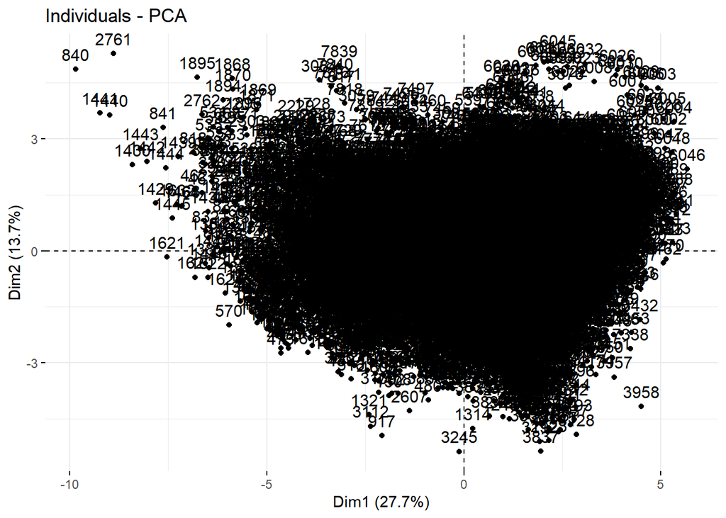

```r
  fviz_pca_ind(pca.dfP,axes = c(1,2) )
```

```r
# Extraction des individus extrêmes
individus_extremes <- c(6045, 6044, 6584, 840, 2761, 7839, 3087, 1621, 570)

# Extraction des lignes correspondantes dans la base de données
bdd_extremes <- df[individus_extremes, ]

# Affichage des individus extrêmes
print(bdd_extremes)
```

```
# A tibble: 9 × 27
  date_debut          date_debut_standard   NO2    O3    NO  PM10 temperature
  <dttm>                            <dbl> <dbl> <dbl> <dbl> <dbl>       <dbl>
1 2024-07-31 09:00:00              45504.     7    38  13.7    43        31.2
2 2024-07-31 08:00:00              45504.    10    15  24.6    40        28.2
3 2024-09-06 17:00:00              45542.    12    28  13.2    10        16.6
4 2023-12-18 17:00:00              45279.    61     7 170.     34         5.1
5 2024-03-08 08:00:00              45359.    64     4 163.     38         7.3
6 2024-10-30 17:00:00              45596.    40    21  78.3    31        18.2
7 2024-03-22 00:00:00              45373     21    15  23.7    26        11.8
8 2024-01-20 08:00:00              45311.    36     5  51      19        -4.5
9 2023-12-07 08:00:00              45267.    24     2  61.5    15         2.5
# ℹ 20 more variables: pression <dbl>, pression_variation_3h <dbl>,
#   humidite <dbl>, point_de_rosee <dbl>, vent_moyen <dbl>, vent_rafales <dbl>,
#   vent_rafales_10min <dbl>, vent_direction <dbl>, temperature_min <dbl>,
#   temperature_max <dbl>, pluie_1h <dbl>, pluie_3h <dbl>, pluie_6h <dbl>,
#   pluie_12h <dbl>, pluie_24h <dbl>, pluie_cumul_0h <dbl>,
#   pluie_intensite <dbl>, pluie_intensite_max_1h <dbl>, jour <dbl>,
#   heure <dbl>
```

## 2.5 Analyse en Composantes Principales avec une seule variable par groupe

### Préparation des Données

#### 1. Sélection des Variables

Nous sélectionnons une seule variable représentative pour chaque groupe de variables similaires, par exemple, pluie_12h pour les précipitations et vent_moyen pour les variables liées au vent.

```r
# Variables principales sélectionnées
selected_vars <- df[, c("NO2", "O3", "NO", "PM10", "temperature", "pression", "humidite",
                        "pluie_12h", "vent_moyen")]

# Variables supplémentaires
sup_vars <- df[, c("pluie_1h", "pluie_3h", "pluie_6h", "pluie_24h", "pluie_cumul_0h",
                   "pluie_intensite", "pluie_intensite_max_1h",
                   "vent_rafales", "vent_rafales_10min", "vent_direction",
                   "temperature_min", "temperature_max", "point_de_rosee",
                   "pression_variation_3h", "heure", "jour")]

# Combiner les deux
df_reduit <- cbind(selected_vars, sup_vars)
```

## Réalisation de l’ACP

L’ACP est réalisée en utilisant les variables sélectionnées comme principales et les autres comme variables supplémentaires.

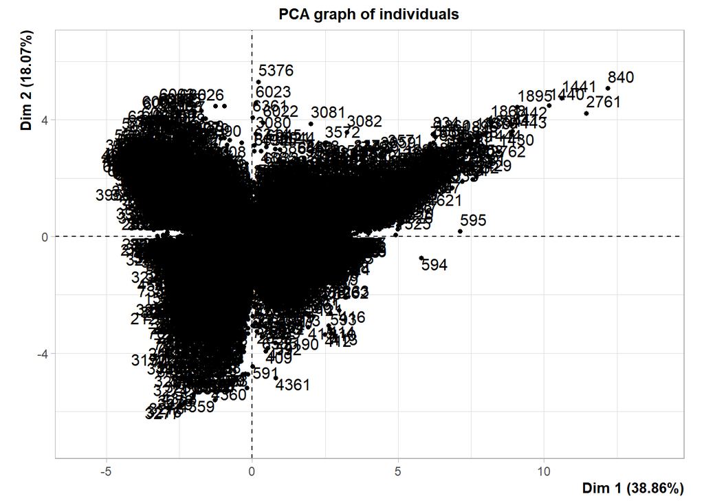

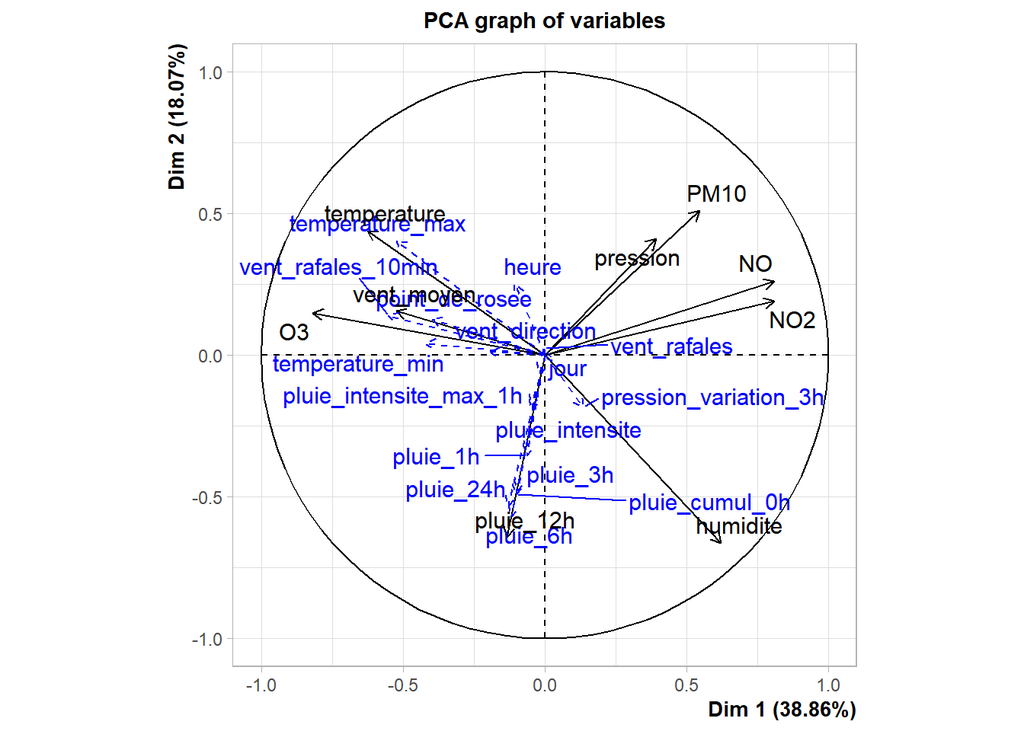

```
       eigenvalue percentage of variance cumulative percentage of variance
comp 1  3.4978247              38.864719                          38.86472
comp 2  1.6265892              18.073213                          56.93793
comp 3  1.1656695              12.951883                          69.88981
comp 4  0.8565851               9.517612                          79.40743
comp 5  0.6073433               6.748259                          86.15569
comp 6  0.5084694               5.649660                          91.80535
comp 7  0.4120634               4.578482                          96.38383
comp 8  0.2122279               2.358088                          98.74192
comp 9  0.1132276               1.258084                         100.00000
```

## Visualisation des Résultats

### Cercle des Corrélations

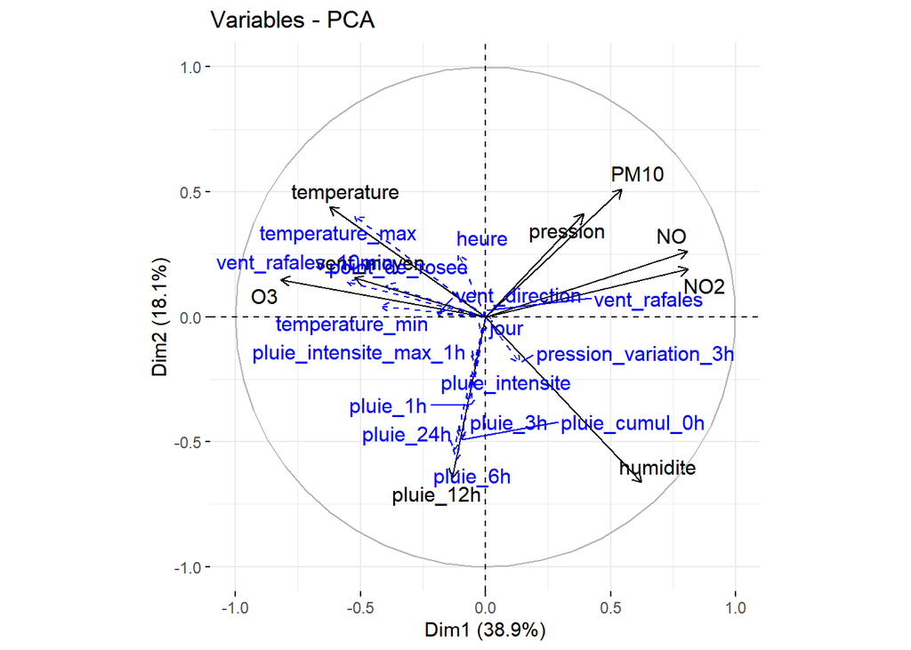

```r
fviz_pca_var(pca.reduit, repel = TRUE)
```

### Plan des Individus

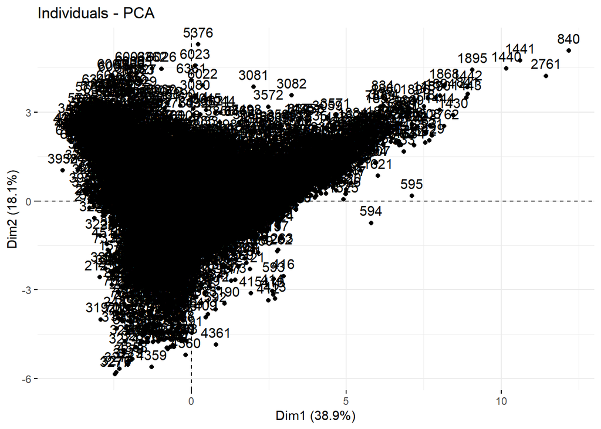

```r
fviz_pca_ind(pca.reduit, axes = c(1, 2))
```